# One-Sided Noncompliance

Shikhar Singh

October 7, 2026

# Agenda

### 1. Potential Outcomes

### 2. Identification Assumptions

### 3. Estimands: ITT, CACE

### 4. Theorem 5.1

### 5. Implications of the Theorem

# Subject Types And Potential Outcomes

**Concept:** Compliance refers to whether actual treatment coincides with assigned treatment (Gerber and Green 2012:131). One-sided non compliance is a case of *failure to treat*: no one in the control group gets treated and some people in the treatment group do not get treated.

So far, we have defined potential outcomes in terms of $Y_i$ and $D_i$. We now develop this framework and distinguish between $d_i$ (treatment status) and $z_i$ (treatment assignment).

Let $d_i(z)$ be a potential outcome that tells us person $i$’s treatment status $d_i$ when their treatment assignment is $z_i$. For example, $d_i(1) = 0$ refers to person $i$ who has been assigned to the treatment group ($z_i=1$) but is **not** treated ($d_i = 0$).

We can now think of four *types* of subjects in any experiment:

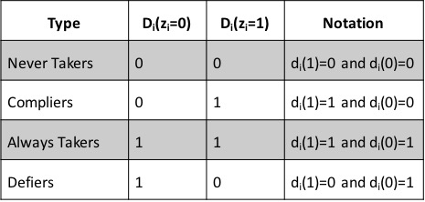

Source: Gerber and Green (2012)

> In one-sided noncompliance we assume no one in the control group gets treated (i.e. there are no “defiers” and “always takers”) but there may be failure to treat in assigned-to-treatment group. In other words, we have two types of subjects: never-takers and compliers.

### Practice

**What does the notation $d_i(1) = 0$ mean?**

It refers to subject $i$ who is assigned to the treatment group ($z_i = 1$) but is untreated. When there is one-sided non-compliance, this refers to never takers.

**How would you read the following potential outcome: $E[Y_i(z_i = 1, d_i = 0) | d_i(1)=0]$?**

$d_i(1) = 0$ is the shorthand for “Never Takers” under one-sided non-compliance. The term gives the expected untreated potential outcome for never takers in the treatment group.

**How is this different from: $E[Y_i(z_i = 1, \color{red}{d_i = 1}) | d_i(1)=0]$?**

This is the expected *treated* potential outcome for never takers ($d_i(1)=0$) in the treatment group.

# Identification Assumptions

With the complexity of non-compliance, there is a need to restate our identification assumptions: non-interference, excludability, and random assignment.

## Non-Intereference

The non-interference assumption has two parts to it:

> “Part A stipulates that whether a subject is treated depends only on the subject’s own treatment group assignment” (FEDAI:138)

$$\begin{equation}
d_i(z) = d_i(z')
\end{equation}$$

(where $z_i = z'_i$ “means that subject $i$ keeps the same treatment assignment even when the assignments of other subjects change)

> “Part B says that the potential outcomes are affected by (1) the subject’s own assignment and (2) the treatment that the subject receives as a consequence of that assignment” (FEDAI:138)

This is the idea we discussed earlier that subject $i$’s potential outcomes are a function of their treatment status ($d_i$) and treatment assignment ($z_i$), and not the treatment status ($d_j$) or treatment assignment ($z_j$) of any other subject $j \neq i$.

Notationally, non-interference implies:

$$\begin{equation}
Y_i(z,d) = Y_i(z',d')
\end{equation}$$

where $z$ and $z'$ are two different treatment assignment vectors in which $i$’s treatment assignment is the same but some or all other subjects’ treatment assignment is different; similarly, $d$ and $d'$ are two different treatment status vectors in which $i$’s treatment status is the same but some or all other subjects’ treatment status is different. In other words, $z_i = z'_i$ and $d_i=d'_i$.

## Excludability

Under one-sided noncompliance, the excludability assumption is this:

> “Potential outcomes respond to treatments [status] not treatment assignments” (FEDAI:140)

Formally:

$$\begin{equation}
Y_i(z,d) = Y_i(d)
\end{equation}$$

Put another way: $Y_i(z=1,d) = Y_i(z=0,d) = Y_i(d)$

## Random Assignment

Under one-sided noncompliance, random assignment implies:

> Treatment assignment $Z_i$ is independent of potential outcomes *and subject types*.

$$\begin{equation}
Z_i \perp\!\!\!\perp \underbrace{Y_i(z, d(z))}_{\text{Potential
Outcomes}},\underbrace{D_i(z)}_{\text{Subject Type}}
\end{equation}$$

In other words, in hypothetical replications of an experiment, being assigned to treatment or control is not predicted either by potential outcomes, or the subjects’ treatment status in response to their assignment (i.e. their “type”).

# Estimands

Ordinarily, experiments tells us about the *average treatment effect*:

$$\begin{equation}
\text{ATE} = E[Y_i(1)] - E[Y_i(0)] = E[Y_i(d=1)] - E[Y_i(d=0)]
\end{equation}$$

When there is noncompliance, we do not have sufficient data to estimate the average treatment effect. One way to think about this is that when there is one-sided noncompliance, we fail to treat some people in the treatment group. For these “never takers”, we do not observe their treated potential outcome, $Y_i(1)$ or $Y_i(d=1)$. Instead, never takers reveal their untreated potential outcome even when they are assigned to the treatment group. As a result, $Y_i(d=1)$ is *missing* for them. This *missing data problem* prevents us from estimating the ATE.

Under noncompliance, we can estimate three quantities:

1. **Intent to Treat Effect (ITT):** This is the difference in means of the treatment and control groups.

$$\begin{equation}
ITT_Y = E[Y_i(z=1,d(1))] - E[Y_i(z=0,d(0))]
\end{equation}$$

Note that $d(1) = d_i(z=1)$ and $d(0) = d_i(z=0)$. For compliers, $d(1)=1$ and $d(0)=0$. For Never Takers $d(1)=d(0)=0$. So the first term in $ITT_Y$ is a weighted average of compliers’ treated potential outcomes and never takers’ untreated potential outcomes, and the second term is a weighted average of untreated outcomes for both.

2. **Compliance ($ITT_D$):** This is the effect of $z_i$ on $d_i$.

$$\begin{equation}
ITT_D = E[d_i(z=1)] - E[d_i(z=0)]
\end{equation}$$

Note that under one-sided noncompliance, $E[d_i(z=0)] = 0$ (no one in the assigned to control group is treated). So $ITT_D$ is essentially the proportion of treated subjects ($d_i=1$) in the assigned-to-treatment group ($z_i=1$). In other words, the proportion of *compliers*.

3. **Complier Average Causal Effect (CACE):** This is the average treatment effect for *compliers*.

$$\begin{equation}
CACE = E[\underbrace{Y_i(d=1) - Y_i(d=0)}_{\text{ATE}} |
\underbrace{d_i(1) = 1}_{\text{Compliers}}]
\end{equation}$$

# Theorem 5.1

Theorem 5.1 shows that CACE (complier average causal effect or the average treatment effect among compliers) is a ratio of two intent-to-treat parameters: the effect of treatment assignment on the outcome $Y_i$ (called $ITT$ or $ITT_Y$); and the effect of treatment assignment on treatment status $D_i$ (called $ITT_D$). More specifically, $CACE = \frac{ITT}{ITT_D}$

*Proof:* Start with the `ITT` or intent-to-treat effect:

$\underbrace{E[Y_i | z_i = 1]}_{\text{Avg Outcome in Trt Group}} - \underbrace{E[Y_i | z_i = 0]}_{\text{Avg Outcome in Control Group}}$

We can rewrite each of these quantities as a weighted average of potential outcomes of different types of subjects:

**In the treatment group:**

$E[Y_i | z_i = 1] = E[Y_i | z_i = 1, d_i = 1]\cdot \pi_C + E[Y_i | z_i = 1, d_i = 0]\cdot(1 - \pi_C)$

where $\pi_C$ is the proportion of compliers in the treatment group. Since we assume there are only two types of subjects, $(1 - \pi_C)$ is the proportion of never takers in the treatment group.

We know that compliers reveal their treated potential outcome or $Y_i(1)$ in the treatment group, and never takers reveal their untreated potential outcome or $Y_i(0)$ in the treatment group. So we can simplify the above expression to read:

$E[Y_i | z_i = 1] = E[Y_i(1) | \text{Complier}]\cdot \pi_C + E[Y_i(0) | \text{NT}]\cdot(1 - \pi_C)$

**In the control group:**

$E[Y_i | z_i = 0] = E[Y_i | z_i = 0, d_i = 0]\cdot \pi_C + E[Y_i | z_i = 0, d_i = 0]\cdot(1 - \pi_C)$

In the control group, both compliers and never takers reveal their untreated potential outcome. So we can simplify this expression to read:

$E[Y_i | z_i = 0] = E[Y_i(0) | \text{Complier}]\cdot \pi_C + E[Y_i(0) | \text{NT}]\cdot(1 - \pi_C)$

**Plugging-in these quantities**

The $ITT$ can be written as a weighted average of types:

$E[Y_i | z_i = 1] - E[Y_i | z_i = 0] = \\\\ \{E[Y_i(z=1,d=1) |\text{C}] - E[Y_i(z=0,d=0) |\text{C}]\} \cdot \pi_C \\\\ + \{E[Y_i(z=1,d=0)| \text{NT}] - E[Y_i(z=0,d=0)| \text{NT}]\}\cdot(1 - \pi_C)$

Since we randomly assigned subjects to treatment groups, and assume excludability (treatment assignment ($z_i$) has no effect on outcomes other than through the treatment ($d_i$) itself), never-takers in the treatment and control groups have the same outcome on average. In other words, $E[Y_i(z_i = 1, d_i = 0)] = E[Y_i(z_i = 0, d_i = 0)]$. The second part of the equation cancels out and we are left with:

$E[Y_i | z_i = 1] - E[Y_i | z_i = 0] = E[Y_i(1) - Y_i(0) |\text{Complier}]\cdot \pi_C$

Re-arranging terms we get:

$E[Y_i(1) - Y_i(0) |\text{Complier}] = \frac{E[Y_i | z_i = 1] - E[Y_i | z_i = 0]}{\pi_C}$

Note that $ITT_D = E[d_i | z_i = 1] - E[d_i | z_i = 0] = \pi_C$ (i.e. the average value of $d_i$ in the treatment group is just the proportion of compliers, and the average value of $d_i$ in the control group is 0 since no one is treated, so the difference is just the proportion of compliers or $\pi_C$).

Theorem 5.1 states exactly this: $CACE = \frac{ITT}{ITT_D} = \frac{E[Y_i | z_i = 1] - E[Y_i | z_i = 0]}{\pi_C}$

Assumptions

Identification of the CACE requires the following four assumptions: random assignment, non-interference, excludability, and $ITT_D > 0$.

# Properties of $\frac{ITT_Y}{ITT_D}$

Gerber and Green (2012) make several important points about the complier average causal effect (p147-9). Here, I discuss three of them in detail.

## Changes in $ITT_D$ and $CACE$

Since the $CACE = \frac{ITT_Y}{ITT_D}$, a misconception may arise that if $ITT_D$ increases, the CACE decreases because we are dividing $ITT_Y$ by a bigger number. This is not the case because ‘increasing the share of compliers also change[s] the numerator [$ITT_Y$], depending on how these extra compliers respond to treatment’ (Gerber and Green 2012:147). This is demonstrated using a small dataset below.

**Task:** Estimate the complier average causal effect for the first four rows of the dataset, then for the full dataset. Does the compliance rate increase or decrease with the additional observation? How does the CACE change as a result of this?

| Unit | Y | Z | D |
| --- | --- | --- | --- |
| 1 | 10 | 1 | 1 |
| 2 | 6 | 1 | 0 |
| 3 | 6 | 0 | 0 |
| 4 | 4 | 0 | 0 |
| 5 | 20 | 1 | 1 |

**Solution**:

Considering only the first four rows:

$ITT_Y = \frac{16}{2} - \frac{10}{2} = 3$

$ITT_D = \frac{1}{2} - 0 = 0.5$

Consequently, $CACE = \frac{3}{0.5} = 6$

Now consider the full dataset:

$ITT_Y = \frac{36}{3} - \frac{10}{2} = 12 - 5 = 7$

$ITT_D = \frac{2}{3} - 0 = 0.667$

And thus, $CACE = \frac{7}{0.667} \approx 10.5$.

**Bottomline:** Both the compliance rate and CACE can increase simultaneously. In this example, $ITT_D$ moved from 0.5 to 0.667; and the $CACE$ from 6 to 10.5. This is because the additional complier reported a high outcome value that considerably increased the $ITT_Y$.

## $\hat{CACE}$ is consistent but biased

We know that the complier average causal effect is a ratio of two quantities: $\frac{ITT_Y}{ITT_D}$. Using some data , we estimate these two quantities: $\hat{ITT_Y}$ and $\hat{ITT_D}$. This ratio ($\frac{\hat{ITT_Y}}{\hat{ITT_D}}$) is a consistent but *biased* estimator of the true CACE.

**Intuition**: We know that $\hat{ITT_Y}$ and $\hat{ITT_D}$ are unbiased estimators of $ITT_Y$ and $ITT_D$. In other words: $E[\hat{ITT_Y}] = ITT_Y$ and $E[\hat{ITT_D}] = ITT_D$. However, ‘the ratio of two unbiased estimators is not an unbiased estimator for the ratio of the two estimands’ (Gerber and Green 2012:151):

$E[\frac{\hat{ITT_Y}}{\hat{ITT_D}}] \neq \frac{E[\hat{ITT_Y}]}{E[\hat{ITT_D}]} = \frac{ITT_Y}{ITT_D}$.

This is because for any two random variables $X$ and $Y$, $E[\frac{X}{Y}] = \frac{E[X] - Cov[\frac{X}{Y},Y]}{E[Y]}$. In our context:

$E[\frac{\hat{ITT_Y}}{\hat{ITT_D}}] = \frac{E[\hat{ITT_Y}] - Cov[\frac{\hat{ITT_Y}}{\hat{ITT_D}},\hat{ITT_D}]}{E[\hat{ITT_D}]} \\\\ = \frac{ITT_Y - Cov[\frac{\hat{ITT_Y}}{\hat{ITT_D}},\hat{ITT_D}]}{ITT_D}$

Which can be stated as the true complier average causal effect plus a bias term:

$\frac{ITT_Y}{ITT_D} - \color{red}{\frac{Cov[\frac{\hat{ITT_Y}}{\hat{ITT_D}},\hat{ITT_D}]}{ITT_D}}$

## Exclusion restriction violations and $ITT_D$

**Claim**: When the $ITT_D$ is close to zero, even a slight violation of the exclusion restriction may severely bias the estimation of the CACE (Gerber and Green 2012:149)

**Proof**: Write the ITT as a weighted average of compliers and never takers

$ITT_Y = \{E[Y_i(z=1,d=1)|\text{C}] - E[Y_i(z=0,d=0) |\text{C}]\} \cdot ITT_D +\\\\ \{E[Y_i(z=1,d=0)|\text{NT}] - E[Y_i(z=0,d=0) |\text{NT}]\}\cdot (1 - ITT_D)$

Now, if we divide the entire equation by $ITT_D$:

$\frac{ITT_Y}{ITT_D} = CACE + \color{red}{\frac{1 - ITT_D}{ITT_D} \{E[Y_i(z=1,d=0)|NT] - E[Y_i(z=0,d=0)|NT]\}}$

Note that if the exclusion restriction holds, $E[Y_i(z=1,d=0)] = E[Y_i(z=0,d=0)]$. But even a slight violation can produce a large bias when $ITT_D$ is small. As $ITT_D \rightarrow 0, \frac{1-ITT_D}{ITT_D} \rightarrow \infty$.